**Deep Learning for Mechanical Engineering**  
**Midterm Exam: Part I**  
**10/16/2023, 6:00 PM to 7:50 PM (110 minutes)**

Prof. Seungchul Lee  
http://iailab.kaist.ac.kr/  
Industrial AI Lab at KAIST

# Problem 1: Optimization

Find $J$ of the below optimization problem with the following objective function and constraint. ($x,\omega, \omega_0 \in \mathbb{R}^n$)

$$ \begin{align*} J = \;\min_x \quad & \rVert x \lVert_2\\ \\ \text{subject to}\quad & \omega^T x + \omega_0 = 0 \end{align*}$$

## Solution

If $x$ is on the line of $\omega_0 + \omega^Tx = 0$, the objective function can be interpreted as the shortest distance $J^{*}$ from origin to the line. We geometrically (or intuitively) know that distance $J$ will be minimal when vector $x$ is orthogonal to the line

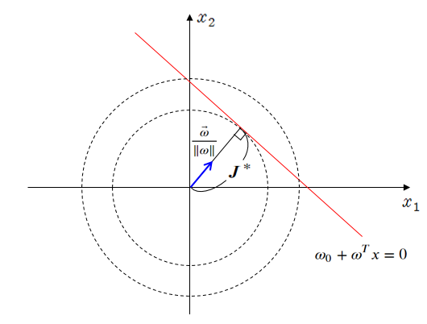

$$ \begin{align} \vec x^* & =J^{*}\frac{\vec \omega}{\lVert \omega \rVert} \\ \\ \omega_0 + \omega^Tx & = \omega_0 + \omega^T\left(J^{*}\frac{\omega}{\lVert \omega \rVert}\right) \\ & = \omega_0 + J^{*}\lVert \omega \rVert = 0 \\ \\ \therefore J^{*} & = -\frac{\omega_0}{\lVert \omega \rVert}\end{align}$$

# Problem 2: Regression

Fit a straight line $y=ax+b$ to the points $(1,2), (2,3), (0,0), (-3,-5)$. You must solve by recasting this problem as least squares.

## Solution

$$\begin{bmatrix}1&1\\2&1\\0&1\\-3&1\end{bmatrix}\begin{bmatrix}a\\b\end{bmatrix}=\begin{bmatrix}2\\3\\0\\-5\end{bmatrix}$$

$$A^TA=\begin{bmatrix}14&0\\0&4\end{bmatrix}, \qquad A^Tb=\begin{bmatrix}23\\0\end{bmatrix}$$
$$\begin{bmatrix}14&0\\0&4\end{bmatrix}x = \begin{bmatrix}23\\0\end{bmatrix}$$
$$\begin{bmatrix}a\\b\end{bmatrix}=\begin{bmatrix}\frac{23}{14}\\0\end{bmatrix}$$
$$\therefore y = \frac{23}{14} x$$

# Problem 3: Gradient Descent

You want to build a classifier that predicts the musical instrument given an audio clip. There are 50 unique types of instruments, and you’ve collected a dataset of sounds of each, first collecting audio clips of guitars, then clips of violins, and so on for all the different instruments.

a) You use batch gradient descent (BGD) to optimize your loss function, but you have been getting poor training loss. You search your code for potential bugs and realize that you’re not shuffling the training data. Would shuffling the training fix this problem? Explain your reasoning.

b) Label the training loss curves A, B, and C with whether they were likely generated with stochastic gradient descent, mini-batch gradient descent, or batch gradient descent (select one for each).

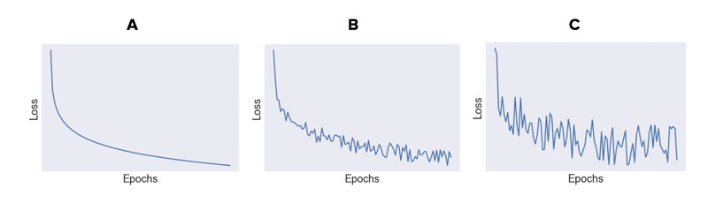

c) You decide to tune your model’s learning rate. What is one typical sign of a learning rate being too small?

d) If the network of yours has the discrete loss function like a step function, which of three gradient descent algorithms will you use? Explain about your choice in detail. (If you think all three gradient descent algorithms written are not suitable to be used, please explain the reason why)

## Solution

a) Shuffling the dataset will not have an impact on the gradients that are used to perform an update, as either way the entire dataset is used (since you are using batch GD).

b) Batch (A), minibatch (B), stochastic (C).

c) Cost function may take a very long time to converge. To detect, look at the costs after each iteration (plot the cost function v.s. the number of iterations). The cost function decreases very slowly. You could also try higher learning rates to see if the performance improves.

d) It is impossible to apply gradient descent algorithm to the discrete loss function. This is because the gradient is zero, which means that weights are not updated.

# Problem 4

(1) What are the advantages (or characteristics) of the logistic regression compared to the perceptron?

(2) What is the advantage of having big data in terms of overfitting issues?

(3) Why do we divide data into training set, and validation (testing) set?

(4) Suggest possible approaches to avoid overfitting.

## Solution (By ChatGPT)

(1) Logistic regression and the perceptron are both binary classification algorithms, but they have some differences in terms of advantages and characteristics. Here are some advantages of logistic regression compared to the perceptron:

1. **Output Probability**: Logistic regression provides output as probabilities. It uses the logistic function to squash the output to a value between 0 and 1, representing the probability of the input belonging to a particular class. The perceptron provides binary output (0 or 1) based on a hard threshold, which doesn't represent probabilistic information.
2. **Continuous and Smooth Transition**: Logistic regression's output varies smoothly as input changes, making it differentiable. This smooth transition allows for gradient-based optimization, making it suitable for various optimization techniques, including gradient descent. The perceptron has a non-smooth transition, making it challenging to optimize using gradient-based methods.
3. **Less Sensitive to Outliers**: Logistic regression is less sensitive to outliers compared to the perceptron. The logistic function constrains output values, which reduces the influence of outliers on the model.
4. **Log-Loss Optimization**: Logistic regression is typically trained using log-loss (cross-entropy) as the loss function, which is a convex function. This enables efficient optimization, ensuring convergence to a global minimum. Perceptron training uses a simple hinge loss, which may not be as well-behaved in optimization.
5. **Well-suited for Probabilistic Classification**: Logistic regression is well-suited for tasks where you need not only class predictions but also probabilistic estimates of class membership. For instance, in medical diagnosis, you might be interested in both the predicted disease class and the probability of having the disease.
6. **Multi-class Classification**: Logistic regression can be extended to handle multi-class classification problems using techniques like one-vs-all (OvA) or softmax regression, making it more versatile.

It's important to note that the choice between logistic regression and the perceptron depends on the specific problem, data characteristics, and modeling requirements. The perceptron is simpler and may work well for linearly separable data, while logistic regression is more flexible and suitable for a broader range of classification tasks.

(2) Big data can have a significant advantage in mitigating the overfitting issue when training machine learning models. Overfitting occurs when a model learns to perform exceptionally well on the training data but fails to generalize to unseen data. Big data helps counteract overfitting in several ways:

1. **Increased Diversity**: With a large and diverse dataset, there is a greater representation of various scenarios and instances. This diversity makes it more challenging for a model to memorize the training data, as it must generalize across a wide range of examples.
2. **Reduced Noise Impact**: No dataset is entirely free from noise or irrelevant data. In small datasets, these noisy data points can disproportionately influence the model. In contrast, big data tends to dilute the impact of noise, making it less likely for the model to overfit to erroneous patterns.
3. **Improved Feature Learning**: In big data scenarios, the model has more opportunities to learn relevant features and patterns from the data. It can focus on the most informative features, reducing the tendency to overfit to idiosyncrasies in the training data.
4. **Better Model Complexity Control**: In complex models, such as deep neural networks, having more data helps regulate the model's capacity. A complex model can capture intricate patterns without overfitting if it has enough data to learn from. Big data allows for more complex models that can handle a wide range of data patterns.
5. **Validation and Cross-Validation**: Big data allows for effective validation and cross-validation techniques. You can set aside large validation sets or perform cross-validation with multiple folds, which provides a better assessment of how the model generalizes.
6. **Regularization**: With big data, you can apply regularization techniques effectively to prevent overfitting. Regularization methods, such as L1 or L2 regularization, penalize overly complex models. They are more effective when you have ample data to train with.
7. **Ensemble Learning**: Big data facilitates the use of ensemble learning methods, like Random Forests or Gradient Boosting. These methods combine multiple models, each trained on a subset of data, which can reduce overfitting and improve overall performance.
8. **Transfer Learning**: In cases where big data is available for a related task, transfer learning becomes more practical. Transfer learning leverages pretrained models on large datasets and fine-tunes them on smaller target datasets. This approach can significantly improve generalization.

While big data offers these advantages against overfitting, it's essential to consider data quality, data preprocessing, and the choice of appropriate machine learning algorithms. Overfitting can still occur if the data is noisy, contains irrelevant features, or if the model architecture is excessively complex. Therefore, big data alone is not a guarantee against overfitting; it must be used in conjunction with sound data science practices.

(3) Splitting data into training and validation (testing) sets serves several essential purposes in machine learning and model development:

1. **Model Development and Training**: The training set is used to train the machine learning model. During training, the model learns patterns, relationships, and features in the data. The goal is to develop a model that captures these patterns and can make accurate predictions or classifications.
2. **Model Evaluation**: The validation (or testing) set is used to evaluate the model's performance. Once the model is trained, it's essential to assess how well it generalizes to new, unseen data. The validation set simulates this real-world performance and provides a reliable estimate of how the model will behave with new data.
3. **Preventing Overfitting**: By splitting the data, you can assess the model's ability to generalize. If a model performs exceptionally well on the training data but poorly on the validation set, it may be overfitting. Overfitting occurs when a model memorizes the training data rather than learning general patterns. Using a separate validation set helps detect and prevent overfitting.
4. **Hyperparameter Tuning**: When optimizing a machine learning model, you often need to fine-tune hyperparameters such as learning rates, regularization strengths, or network architectures. The validation set allows you to evaluate different hyperparameter choices and select those that result in the best model performance.
5. **Early Stopping**: Monitoring the model's performance on the validation set can help with early stopping. If the validation performance starts to degrade, it might be a sign that the model is overfitting. Early stopping is a technique used to stop training when the model's performance on the validation set no longer improves, thereby avoiding overfitting.
6. **Cross-Validation**: In some cases, data is split into multiple subsets, often referred to as "folds." Cross-validation techniques, such as k-fold cross-validation, involve training and evaluating the model multiple times on different data subsets. This provides a more robust estimate of the model's generalization performance.
7. **Assessing Model Robustness**: Testing a model on a separate validation set helps assess its robustness. It allows you to see how the model responds to variations in the data, including noise, outliers, and changes in the underlying distribution.
8. **Model Selection**: In cases where you're comparing multiple models (e.g., different algorithms or architectures), the validation set helps select the best-performing model. You can choose the model that exhibits the highest validation performance.

In summary, dividing data into training and validation (testing) sets is crucial for building, evaluating, and optimizing machine learning models. This practice ensures that models are capable of generalizing to new, unseen data, which is a fundamental requirement for their real-world applicability.

(4) Overfitting is a common problem in machine learning, where a model performs well on the training data but poorly on unseen data. To avoid overfitting and build models that generalize effectively, consider the following approaches:

1. **More Data**: One of the most effective ways to reduce overfitting is to increase the size of your training dataset. More data allows the model to capture underlying patterns and relationships without memorizing the training examples.
2. **Data Augmentation**: Augmenting your training data by creating variations of existing samples (e.g., rotations, translations, or flips for images) can increase the diversity of the dataset and improve generalization.
3. **Feature Selection**: Choose relevant features and discard irrelevant ones. Feature selection can reduce the model's complexity and prevent it from fitting noise in the data.
4. **Regularization**: Regularization techniques, such as L1 (Lasso) and L2 (Ridge) regularization, add penalty terms to the model's loss function. These penalties discourage the model from assigning very high weights to certain features. Regularization can be applied to linear regression, logistic regression, and neural networks, among others.
5. **Cross-Validation**: Use techniques like k-fold cross-validation to assess your model's performance on different subsets of the data. This helps you evaluate the model's generalization and detect overfitting.
6. **Early Stopping**: Monitor the model's performance on a validation set during training. If the validation performance starts to degrade, stop training to prevent overfitting. This is particularly useful for deep learning models.
7. **Reduce Model Complexity**: Use simpler models or architectures with fewer parameters. For example, in deep learning, you can reduce the number of layers and neurons in a neural network. A less complex model is less prone to overfitting.
8. **Ensemble Methods**: Combine predictions from multiple models (e.g., bagging, boosting, or stacking). Ensemble methods can improve generalization by reducing the impact of overfitting in individual models.
9. **Dropout**: In neural networks, dropout is a regularization technique that randomly deactivates a fraction of neurons during each training iteration. This helps prevent the model from relying too heavily on specific neurons and increases generalization.
10. **Pruning**: In decision trees or random forests, pruning involves removing branches or subtrees that do not contribute significantly to improving the model's performance. Pruning simplifies the model and reduces overfitting.
11. **Cross-Validation for Hyperparameter Tuning**: When optimizing hyperparameters (e.g., learning rates, regularization strengths, or network architectures), use cross-validation to assess the model's performance across different hyperparameter values. Choose the values that yield the best cross-validation results.
12. **Feature Engineering**: Transform and engineer features to represent data more effectively. Proper feature engineering can make the dataset more suitable for the chosen model and reduce the risk of overfitting.
13. **One-Hot Encoding and Embeddings**: When dealing with categorical variables, use one-hot encoding or embeddings instead of arbitrary integer encodings. This helps the model understand the relationships between categories.
14. **Collect More Diverse Data**: Ensure that your training data is diverse and representative of the problem you want to solve. Bias in the training data can lead to biased models.
15. **Regularize the Neural Network**: In deep learning, techniques like weight decay, batch normalization, and gradient clipping can help regularize neural networks.
16. **Cross-Validation with Shuffled Data**: Perform cross-validation with shuffled data to ensure that the model generalizes well regardless of the input's order.

These approaches can be used individually or in combination, depending on the specific problem and the type of model you are working with. It's essential to strike a balance between model complexity and model performance, ensuring that your model generalizes well to new data.

# Problem 5: Single-Layer and Multi-Layer Perceptron (Sigmoid)

a)

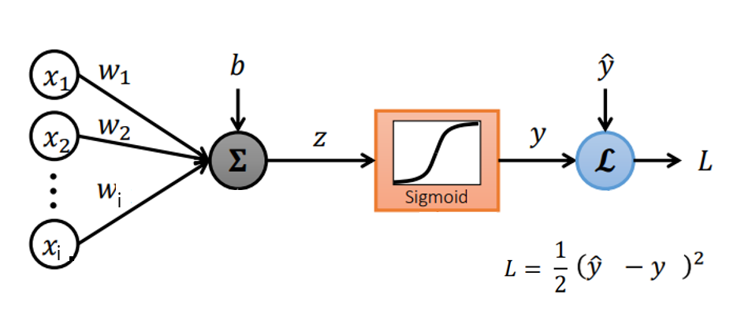

The image above depicts a training process of a single layer perceptron. Express $\frac{\partial{L}}{\partial{w_i}}$ in terms of $x_i$, $\hat{y}$, and ${y}$.

b) Explain why gradient vanishing occurs as the model with sigmoid activation function goes deeper.

- Use the chain rule to explain gradient vanishing centering on $\omega_1$, $\omega_2$ and $\omega_3$.

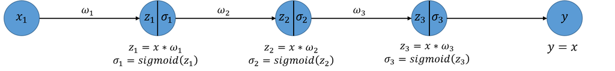

## Solution

a)

$$ \begin{align*} \frac{\partial{L}}{\partial{w_i}} = \frac{\partial{z}}{\partial{w_i}} \times \frac{\partial{y}}{\partial{z}} \times\frac{\partial{L}}{\partial{y}} \\\\ \end{align*} $$$$ \begin{align*} \frac{\partial{L}}{\partial{w_i}} = - x_i \times y \times (1-y) \times (\hat{y}-y) \\\\ \end{align*} $$

b)

**$w_3$ update**

$$ \begin{align*} \\\\ \frac{\partial E}{\partial \omega_3} = \frac{\partial E}{\partial \sigma_3} \times \frac{\partial \sigma_3}{\partial z_3} \times \frac{\partial z_3}{\partial \omega_3} \\\\ \end{align*} $$$$ \begin{align*} \frac{\partial \sigma_3}{\partial z_3} = \sigma_3 \times (1 - \sigma_3) \\\\ \end{align*} $$

**$w_2$ update**

$$ \begin{align*} \\\\ \frac{\partial E}{\partial \omega_2} = \frac{\partial E}{\partial \sigma_3} \times \frac{\partial \sigma_3}{\partial z_3} \times \frac{\partial z_3}{\partial \sigma_2} \times \frac{\partial \sigma_2}{\partial z_2} \times \frac{\partial z_2}{\partial \omega_2} \\\\ \end{align*} $$$$ \begin{align*} \frac{\partial \sigma_2}{\partial z_2} = \sigma_2 \times (1 - \sigma_2) \space, \space \space \space \space \space \frac{\partial \sigma_3}{\partial z_3} = \sigma_3 \times (1 - \sigma_3) \\\\ \end{align*} $$

**$w_1$ update**

$$ \begin{align*} \\\\ \frac{\partial E}{\partial \omega_1} = \frac{\partial E}{\partial \sigma_3} \times \frac{\partial \sigma_3}{\partial z_3} \times \frac{\partial z_3}{\partial \sigma_2} \times \frac{\partial \sigma_2}{\partial z_2} \times \frac{\partial z_2}{\partial \sigma_1} \times \frac{\partial \sigma_1}{\partial z_1} \times \frac{\partial z_1}{\partial \omega_1} \\\\ \end{align*} $$$$ \begin{align*} \frac{\partial \sigma_1}{\partial z_1} = \sigma_1 \times (1 - \sigma_1) \space, \space \space \space \space \space \frac{\partial \sigma_2}{\partial z_2} = \sigma_2 \times (1 - \sigma_2) \space, \space \space \space \space \space \frac{\partial \sigma_3}{\partial z_3} = \sigma_3 \times (1 - \sigma_3) \\\\ \end{align*} $$

The deeper the layer, the more derivative terms of the sigmoid function. Since the sigmoid function always has a value less than 1, the gradient gradually converges to 0 as the layer gets deeper.

# Problem 6

Suppose a multi-layer perceptron which has an input layer with 10 neurons, a hidden layer with 50 neurons, and an output layer with 3 neurons. Non-linear activation function for every neurons are ReLU. Write your answer to the following questions.

(1) Size of input $X$?

(2) Size of weights and biases $(W_h, b_h)$ for the hidden layer?

(3) Size of weights and biases $(W_o,b_o)$ for the output layer?

(4) Size of output $Y$?

(5) Write output $Y$ as a function of $X, W_h, b_h, W_o, b_o$ (Use ReLU as a non-linear activation function)

## Solution

(1) Size of $X$ is $m \times 10$ where $m$ is batch size.

(2) $$W_h\space :\space10\times50 \\b_h\space:\space50$$

(3) $$W_o\space :\space50\times3 \\b_o\space:\space3$$

(4) Size of $Y$ is $m\times 3$ where $m$ is batch size.

(5) $Y = ReLU(ReLU(X \cdot W_h+b_h) \cdot W_o+b_o)$

# Problem 7: Multiple Choice

For each of the following questions, choose correct options. Each question has **AT LEAST** one correct option. No explanation is required.

a) Which of the following is true about dropout?

1. Dropout leads to sparsity in the trained weights
2. At test time, dropout is applied with probability maintained
3. The larger the keep probability of a layer, the stronger the regularization of the weights in that layer
4. None of the above

b) During backpropagation, as the gradient flows backward through a sigmoid function, the gradient will always:

1. Increase in magnitude
2. Decrease in magnitude
3. Maintain sign
4. Reverse sign

c) You are training a large feedforward neural network (100 layers) on a binary classification task, using a sigmoid activation in the final layer, and a mixture of tanh and ReLU activations for all other layers. You notice your weights to your a subset of your layers stop updating after the first epoch of training, even though your network has not yet converged. Which of the following fixes could help? (You also note that your loss is still within a reasonable order of magnitude).

1. Increase the size of your training set
2. Switch the ReLU activations with leaky ReLUs everywhere
3. Add Batch Normalization before every activation
4. Increase the learning rate

## Solution

a) 4

b) 2, 3

c) 2, 3

# Problem 8: CNN

Two historians approach you for your deep learning expertise. They want to classify images of historical objects into 3 classes depending on the time they were created:

- Antiquity ($y = 0$)
- Middle Ages ($y = 1$)
- Modern Era ($y = 2$)

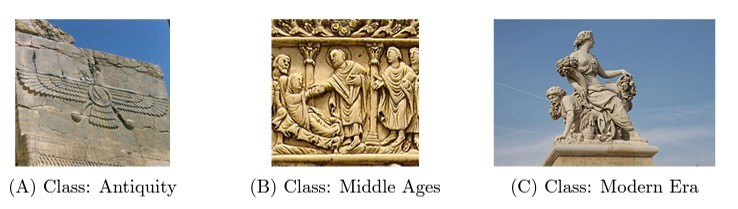

a) Over the last few years, the historians have collected nearly 5,000 hand-labelled RGB images. Before training your model, you want to decide the image resolution to be used. Why is the choice of image resolution important?

b) You have now figured out a good image resolution to use. How would you partition your dataset? Formulate your answer in percentages.

c) After visually inspecting the dataset, you realize that the training set only contains pictures taken during the day, whereas the validation set only has pictures taken at night. Explain what is the issue and how you would correct it.

d) As you train your model, you realize that you do not have enough data. Cite 3 data augmentation techniques that can be used to overcome the shortage of data.

e) You come up with a CNN classifier. For each layer, calculate the number of weights, number of biases and the size of the associated feature maps. The notation follows the convention:

- CONV-K-N denotes a convolutional layer with $N$ filters, each them of size $K \times K$. Padding and stride parameters are always $0$ and $1$, respectively.
- POOL-K indicates a $K \times K$ pooling layer with stride $K$ and padding $0$.
- FC-N stands for a fully-connected layer with $N$ neurons.

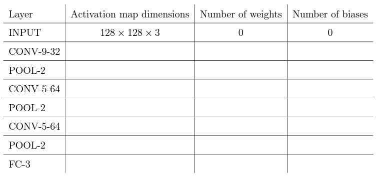

f) Why is it important to place non-linearities between the layers of neural networks?

g) Following the last FC-3 layer of your network, what activation must be applied? Given a vector $a = [0.3,0.3,0.3]$, what is the result of using your activation on this vector?

## Solution

a) Trade-off between accuracy and model complexity.

b) Several ratios possible. One way of doing it: split the initial dataset into 64% training/16% dev/20% testing set. Training on the training set and tuning the hyperparameters after looking at the performance on the dev set.

c)

- It can cause a domain mismatch.
- The difference in the distribution of the images between training and dev might lead to faulty hyperparameter tuning on the dev set, resulting in poor performance on unseen data.
- Solution: randomly mix pictures taken at day and at night in the two sets and then resplit the data.

d) A lot of answers can be accepted, including Rotation, Cropping, Flipping, Luminosity/Contrast Changes

e)

- $120×120×32$ and $32×(9×9×3+1)$
- $60×60×32$ and $0$
- $56×56×64$ and $64×(5×5×32+1)$
- $28×28×64$ and $0$
- $24×24×64$ and $64×(5×5×64+1)$
- $12×12×64$ and $0$
- $3$ and $3×(12×12×64+1)$

f) Non-linearity introduces more degrees of freedom to the model. It lets it capture more complex representations which can be used towards the task at hand. A deep neural network without non-linearities is essentially a linear regression.

g) Softmax is the one that is used as it can output class probabilities. Output is [0.33, 0.33, 0.33]. (You don’t need a calculator!)

# Problem 9: Class Activation Map

Suppose three matrixes below represent the outputs from the last convolution layer and $w$ represents the weight. Find the class activation map.

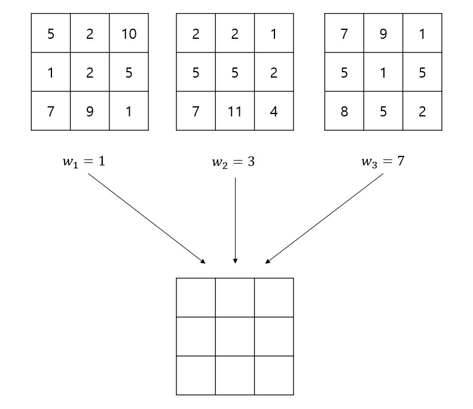

## Solution

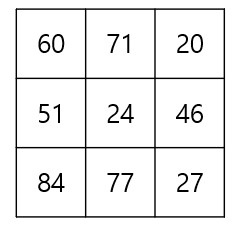